# Pregunta 11

Para observar los efectos de un medicamento, este se inyecta en un animal y se registra el comportamiento de la temperatura (ºC) en función del tiempo (horas), como lo muestra la gráfica.

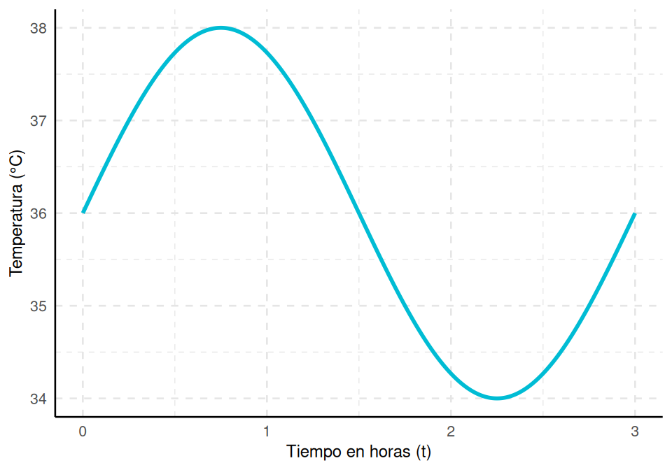

¿Cuál de las siguientes expresiones corresponde a la curva que describe la temperatura del animal en función del tiempo?

**A.**

$$\boxed{F(t) = 2 \cos \left(
\frac{2\pi}{3} t \right) + 36}$$

**B.**

$$\boxed{F(t) = 3 \cos \left(
\frac{2\pi}{3} t \right) + 38}$$

**C.**

$$\boxed{F(t) = 2 \sin \left(
\frac{2\pi}{3} t \right) + 36}$$

**D.**

$$\boxed{F(t) = 3 \sin \left(
\frac{2\pi}{3} t \right) + 38}$$

### Análisis

El código genera una curva de temperatura usando la función:
$$\text{temp} = 36 + 2 \cdot
\sin\left(\frac{2\pi}{3} t\right)$$

- **Amplitud**: $2 \, \text{ºC}$ (oscilación entre $36 \pm 2$).
- **Periodo**: $\frac{2\pi}{\frac{2\pi}{3}} = 3 \, \text{horas}$.
- **Desplazamiento vertical**: $+36 \, \text{ºC}$.
- **Fase inicial**: $\sin(0) = 0$, por lo que en $t = 0$, $\text{temp} = 36 \, \text{ºC}$.

## **Evaluación de las Opciones**

### **Opción A**:

$$F(t) = 2 \cos\left(\frac{2\pi}{3}
t\right) + 36$$
- **Problema**: Usa $\cos$, pero en el código se usa $\sin$.
- **En $t = 0$**: $\cos(0) = 1$, entonces $F(0) = 2 \cdot 1 + 36 = 38 \, \text{ºC}$, lo que **no coincide** con la gráfica (debe empezar en $36 \, \text{ºC}$).
- **Incorrecta**.

### **Opción B**:

$$F(t) = 3 \cos\left(\frac{2\pi}{3}
t\right) + 38$$
- **Amplitud errónea**: $3 \, \text{ºC}$ (debería ser $2 \, \text{ºC}$).
- **Desplazamiento vertical incorrecto**: $+38 \, \text{ºC}$ (debería ser $+36 \, \text{ºC}$).
- **Incorrecta**.

### **Opción C**:

$$F(t) = 2 \sin\left(\frac{2\pi}{3}
t\right) + 36$$
- **Amplitud correcta**: $2 \, \text{ºC}$.
- **Periodo correcto**: $3 \, \text{horas}$.
- **Desplazamiento vertical correcto**: $+36 \, \text{ºC}$.
- **En $t = 0$**: $\sin(0) = 0$, entonces $F(0) = 36 \, \text{ºC}$, coincidiendo con la gráfica.
- **Correcta**.

### **Opción D**:

$$F(t) = 3 \sin\left(\frac{2\pi}{3}
t\right) + 38$$
- **Amplitud errónea**: $3 \, \text{ºC}$.
- **Desplazamiento vertical incorrecto**: $+38 \, \text{ºC}$.
- **Incorrecta**.

## **Respuesta Correcta**

**Opción C**:
$$F(t) = 2 \sin\left(\frac{2\pi}{3} t\right)
+ 36$$

- **Cumple** con amplitud, periodo, desplazamiento vertical y comportamiento inicial.

### Análisis de la Pregunta 2023-Matematicas-11-1-11, según SABER 11 ICFES

- Nivel de Desempeño: 4
- Competencia: Interpretación y Representación
  - Afirmación: Comprende y transforma la información cuantitativa y esquemática presentada en distintos formatos
  - Evidencia: Da cuenta de las características básicas de la información presentada en diferentes formatos como series, gráficas, tablas y esquemas
- Componente: Numérico-Variacional
- Estándar Asociado: Analizo las relaciones y propiedades entre las expresiones algebraicas y las gráficas de funciones polinómicas y racionales y de sus derivadas.
- ¿Qué evalúa?: La capacidad de identificar la función trigonométrica que modela un fenómeno periódico presentado gráficamente, reconociendo sus parámetros (amplitud, periodo, desplazamiento vertical).
- Respuesta Correcta: C, porque $F(t) = 2\sin(\frac{2\pi}{3}t) + 36$ coincide con:
  - Amplitud de 2°C
  - Periodo de 3 horas
  - Desplazamiento vertical de 36°C
  - Comportamiento inicial en t=0 de 36°C
- Distractores:
  1. Opción A: $F(t) = 2\cos(\frac{2\pi}{3}t) + 36$
     - El estudiante confunde seno con coseno
     - No verifica que en t=0 la función debe valer 36°C
     - No analiza que el coseno inicia en su valor máximo
  2. Opción B: $F(t) = 3\cos(\frac{2\pi}{3}t) + 38$
     - El estudiante:
       - No identifica la amplitud correcta en la gráfica
       - No reconoce el desplazamiento vertical adecuado
       - Confunde seno con coseno
       - No verifica valores iniciales
  3. Opción D: $F(t) = 3\sin(\frac{2\pi}{3}t) + 38$
     - El estudiante:
       - Identifica correctamente el uso de seno
       - Pero no determina la amplitud observando la gráfica
       - No reconoce el desplazamiento vertical correcto
       - No verifica valores extremos
- Contenidos Matemáticos Curriculares:
  - Álgebra y Cálculo
  - Periodo 3
    - Funciones trigonométricas
      - Propiedades básicas, rango y periodicidad
- No Genérico
- Eje Axial Disciplinar: Funciones II (Comportamientos Funcionales)
- Tarea: Identificar la función trigonométrica que modela un fenómeno periódico a partir de sus características gráficas.
- Grado: 10° - 11°